# Data Screening Part 1

Ziyuan Huang

Last Updated: 2025-12-18

# Data Screening

- **Garbage in, garbage out:**
  - Data screening is a key facet of any analysis.
  - Data that is incorrect will produce useless output.
  - Data screening ensures the results are interpretable.
- **Our check should include for:**
  - Accuracy,
  - Missing data,
  - Outliers, and
  - Assumptions.
- Note that **assumptions checks may depend on the type** of test because there are **different tests.**

# An Important Note

- **Normally our $\alpha$ value is set to < 0.05, other-wise known as a Type 1 Error.**
  - Therefore, we use p < .05 as a criterion for statistical significance.
- **In data screening, we want to use a stricter criterion.**
  - Therefore, we are going to use p < .001 to denote problematic issues.

# What Order Should be followed?

- 1. Accuracy Check,
- 2. Missing Data Check,
- 3. Outliers Check, and
- 4. Assumptions for the analysis performed.
- **Assumptions include:**
  - Additivity
  - Normality
  - Linearity
  - Homogeneity
  - Homoscedasticity

# Why is this the order?

- If you correct errors - they may become missing data points.
- If you replace missing data - they may become outliers.
- If you exclude outliers, this may change assumption interpretations.
- Therefore: each step can potentially affect the next steps.

# Data Screening Example

- While we have not covered any specific analyses yet, we can screen data overall that will cover many different types of analyses.
- This dataset examines the resiliency (RS columns) of teenagers after a natural disaster.

```r
library(rio)
master <- import("data/data_screening.csv")
str(master)
```

```
## 'data.frame':    137 obs. of  20 variables:
##  $ Sex     : int  1 1 1 1 1 1 1 1 1 1 ...
##  $ Age     : int  17 16 13 15 16 15 12 14 13 18 ...
##  $ SES     : int  2 3 2 3 2 3 3 3 1 3 ...
##  $ Grade   : int  11 7 5 6 11 7 4 6 4 9 ...
##  $ Absences: int  2 2 2 2 6 2 1 2 2 5 ...
##  $ RS1     : int  6 7 5 5 7 7 1 2 6 7 ...
##  $ RS2     : int  4 1 NA 5 4 7 6 3 6 6 ...
##  $ RS3     : int  2 1 5 5 4 7 NA 2 7 5 ...
##  $ RS4     : int  2 5 7 7 7 7 1 3 6 NA ...
##  $ RS5     : int  4 7 4 5 4 7 4 2 1 6 ...
##  $ RS6     : int  7 7 6 6 4 7 7 3 4 6 ...
##  $ RS7     : int  7 7 7 5 7 7 7 3 6 10 ...
##  $ RS8     : int  4 7 6 7 7 7 NA 3 6 7 ...
##  $ RS9     : int  5 4 6 6 4 7 NA 2 2 7 ...
##  $ RS10    : int  7 7 7 7 7 7 4 2 5 7 ...
##  $ RS11    : int  4 1 NA 6 7 7 3 3 6 5 ...
##  $ RS12    : int  7 7 5 6 4 7 7 3 6 6 ...
##  $ RS13    : int  4 4 7 6 7 7 7 2 6 6 ...
##  $ RS14    : int  7 7 6 6 4 7 7 3 2 6 ...
##  $ Health  : int  6 6 2 2 6 4 3 6 1 5 ...
```

# Accuracy

- We will want to check for several issues:
  - Any factor variables incorrectly imported as numbers.
  - Any reverse coded variables.
  - Any out of range values or incorrect values.
  - Other errors depending on data collection procedure.

# Accuracy: Categorical Variables

```r
notypos <- master #update the dataset with each step
apply(notypos[ , c("Sex", "SES")], 2, table)
```

```
##   Sex SES
## 1  64   9
## 2  72  56
## 3   1  72
```

```r
#3 here for sex is probably incorrect
```

# Accuracy: Categorical Variables

- We can use `factor()` but not include the bad label to drop that incorrect point.
- You can also exclude it as shown in a few slides.

```r
## fix the categorical labels and typos
notypos$Sex <- factor(notypos$Sex,
                     levels = c(1,2), #no 3
                     labels = c("Women", "Men"))
notypos$SES <- factor(notypos$SES,
                     levels = c(1,2, 3),
                     labels = c("Low", "Medium", "High"))
apply(notypos[ , c("Sex", "SES")], 2, table)
```

```
## $Sex
##
##   Men Women
##    72    64
##
## $SES
##
##   High    Low Medium
##     72      9     56
```

# Accuracy: Continuous Variables

```r
summary(notypos)
```

```
##     Sex          Age            SES         Grade           Absences
##  Women:64   Min.   :11.00   Low   : 9   Min.   : 1.000   Min.   : 1.000
##  Men  :72   1st Qu.:13.00   Medium:56   1st Qu.: 4.000   1st Qu.: 2.000
##  NA's : 1   Median :15.50   High  :72   Median : 6.000   Median : 2.000
##             Mean   :15.05               Mean   : 5.883   Mean   : 3.358
##             3rd Qu.:17.00               3rd Qu.: 8.000   3rd Qu.: 5.000
##             Max.   :18.00               Max.   :35.000   Max.   :35.000
##             NA's   :5
##       RS1             RS2             RS3             RS4            RS5
##  Min.   :1.000   Min.   :1.000   Min.   : 1.00   Min.   :1.00   Min.   :1.000
##  1st Qu.:4.000   1st Qu.:4.000   1st Qu.: 3.00   1st Qu.:3.00   1st Qu.:3.000
##  Median :5.000   Median :5.000   Median : 4.00   Median :5.00   Median :4.000
##  Mean   :4.858   Mean   :4.962   Mean   : 4.42   Mean   :4.55   Mean   :4.448
##  3rd Qu.:6.000   3rd Qu.:6.000   3rd Qu.: 6.00   3rd Qu.:7.00   3rd Qu.:6.750
##  Max.   :7.000   Max.   :7.000   Max.   :18.00   Max.   :7.00   Max.   :7.000
##  NA's   :3       NA's   :5       NA's   :6       NA's   :6      NA's   :3
##       RS6         RS7              RS8             RS9             RS10
##  Min.   :1   Min.   : 1.000   Min.   :1.000   Min.   :1.000   Min.   :1.000
##  1st Qu.:4   1st Qu.: 4.000   1st Qu.:3.000   1st Qu.:4.000   1st Qu.:4.000
##  Median :5   Median : 5.000   Median :5.000   Median :5.000   Median :5.500
##  Mean   :5   Mean   : 5.082   Mean   :4.764   Mean   :4.692   Mean   :5.313
##  3rd Qu.:7   3rd Qu.: 7.000   3rd Qu.:7.000   3rd Qu.:6.000   3rd Qu.:7.000
##  Max.   :7   Max.   :10.000   Max.   :7.000   Max.   :7.000   Max.   :7.000
##  NA's   :7   NA's   :3        NA's   :10      NA's   :7       NA's   :3
##       RS11            RS12            RS13             RS14
##  Min.   :1.000   Min.   :1.000   Min.   : 1.000   Min.   :1.00
##  1st Qu.:3.000   1st Qu.:5.000   1st Qu.: 4.000   1st Qu.:4.00
##  Median :5.000   Median :6.000   Median : 6.000   Median :5.00
##  Mean   :4.641   Mean   :5.552   Mean   : 5.507   Mean   :4.97
##  3rd Qu.:6.500   3rd Qu.:7.000   3rd Qu.: 7.000   3rd Qu.:7.00
##  Max.   :7.000   Max.   :7.000   Max.   :15.000   Max.   :7.00
##  NA's   :6       NA's   :3       NA's   :3        NA's   :5
##      Health
##  Min.   :1.000
##  1st Qu.:2.000
##  Median :4.000
##  Mean   :3.839
##  3rd Qu.:6.000
##  Max.   :7.000
##
```

# How do we “fix” issues?

- Find the original data and **figure out what the point should be**.
- **Delete that data point** but not the entire participant.

# Accuracy: Continuous Variables

- When you have an inaccurate value in one or only a few columns, you can fix those values using logical operators that we discussed in our subsetting section.
- In this example, we know that students could not have missed more than 15 days.
- They cannot be more than 12 for Grade.

```r
summary(notypos$Grade)
```

```
##    Min. 1st Qu.  Median    Mean 3rd Qu.    Max.
##   1.000   4.000   6.000   5.883   8.000  35.000
```

```r
notypos$Grade[ notypos$Grade > 12 ] <- NA
summary(notypos$Grade)
```

```
##    Min. 1st Qu.  Median    Mean 3rd Qu.    Max.    NA's
##   1.000   4.000   6.000   5.669   8.000  11.000       1
```

```r
summary(notypos$Absences)
```

```
##    Min. 1st Qu.  Median    Mean 3rd Qu.    Max.
##   1.000   2.000   2.000   3.358   5.000  35.000
```

```r
notypos$Absences[ notypos$Absences > 15 ] <- NA
summary(notypos$Absences)
```

```
##    Min. 1st Qu.  Median    Mean 3rd Qu.    Max.    NA's
##   1.000   2.000   2.000   3.125   5.000   7.000       1
```

# Accuracy: Continuous Variables

- When you have inaccurate values for columns that all have the same possible range, you can use the subsetting rules across all columns at once.

```r
names(notypos)
```

```
##  [1] "Sex"      "Age"      "SES"      "Grade"    "Absences" "RS1"
##  [7] "RS2"      "RS3"      "RS4"      "RS5"      "RS6"      "RS7"
## [13] "RS8"      "RS9"      "RS10"     "RS11"     "RS12"     "RS13"
## [19] "RS14"     "Health"
```

```r
head(notypos[ , 6:19]) #lots of ways to do this part!
```

```
##   RS1 RS2 RS3 RS4 RS5 RS6 RS7 RS8 RS9 RS10 RS11 RS12 RS13 RS14
## 1   6   4   2   2   4   7   7   4   5    7    4    7    4    7
## 2   7   1   1   5   7   7   7   7   4    7    1    7    4    7
## 3   5  NA   5   7   4   6   7   6   6    7   NA    5    7    6
## 4   5   5   5   7   5   6   5   7   6    7    6    6    6    6
## 5   7   4   4   7   4   4   7   7   4    7    7    4    7    4
## 6   7   7   7   7   7   7   7   7   7    7    7    7    7    7
```

```r
notypos[ , 6:19][ notypos[ , 6:19] > 7 ] <- NA
summary(notypos)
```

```
##     Sex          Age            SES         Grade           Absences
##  Women:64   Min.   :11.00   Low   : 9   Min.   : 1.000   Min.   :1.000
##  Men  :72   1st Qu.:13.00   Medium:56   1st Qu.: 4.000   1st Qu.:2.000
##  NA's : 1   Median :15.50   High  :72   Median : 6.000   Median :2.000
##             Mean   :15.05               Mean   : 5.669   Mean   :3.125
##             3rd Qu.:17.00               3rd Qu.: 8.000   3rd Qu.:5.000
##             Max.   :18.00               Max.   :11.000   Max.   :7.000
##             NA's   :5                   NA's   :1        NA's   :1
##       RS1             RS2             RS3             RS4            RS5
##  Min.   :1.000   Min.   :1.000   Min.   :1.000   Min.   :1.00   Min.   :1.000
##  1st Qu.:4.000   1st Qu.:4.000   1st Qu.:3.000   1st Qu.:3.00   1st Qu.:3.000
##  Median :5.000   Median :5.000   Median :4.000   Median :5.00   Median :4.000
##  Mean   :4.858   Mean   :4.962   Mean   :4.315   Mean   :4.55   Mean   :4.448
##  3rd Qu.:6.000   3rd Qu.:6.000   3rd Qu.:6.000   3rd Qu.:7.00   3rd Qu.:6.750
##  Max.   :7.000   Max.   :7.000   Max.   :7.000   Max.   :7.00   Max.   :7.000
##  NA's   :3       NA's   :5       NA's   :7       NA's   :6      NA's   :3
##       RS6         RS7             RS8             RS9             RS10
##  Min.   :1   Min.   :1.000   Min.   :1.000   Min.   :1.000   Min.   :1.000
##  1st Qu.:4   1st Qu.:4.000   1st Qu.:3.000   1st Qu.:4.000   1st Qu.:4.000
##  Median :5   Median :5.000   Median :5.000   Median :5.000   Median :5.500
##  Mean   :5   Mean   :5.008   Mean   :4.764   Mean   :4.692   Mean   :5.313
##  3rd Qu.:7   3rd Qu.:7.000   3rd Qu.:7.000   3rd Qu.:6.000   3rd Qu.:7.000
##  Max.   :7   Max.   :7.000   Max.   :7.000   Max.   :7.000   Max.   :7.000
##  NA's   :7   NA's   :5       NA's   :10      NA's   :7       NA's   :3
##       RS11            RS12            RS13            RS14          Health
##  Min.   :1.000   Min.   :1.000   Min.   :1.000   Min.   :1.00   Min.   :1.000
##  1st Qu.:3.000   1st Qu.:5.000   1st Qu.:4.000   1st Qu.:4.00   1st Qu.:2.000
##  Median :5.000   Median :6.000   Median :6.000   Median :5.00   Median :4.000
##  Mean   :4.641   Mean   :5.552   Mean   :5.364   Mean   :4.97   Mean   :3.839
##  3rd Qu.:6.500   3rd Qu.:7.000   3rd Qu.:7.000   3rd Qu.:7.00   3rd Qu.:6.000
##  Max.   :7.000   Max.   :7.000   Max.   :7.000   Max.   :7.00   Max.   :7.000
##  NA's   :6       NA's   :3       NA's   :5       NA's   :5
```

# Accuracy: Continuous Variables

- Using mean and standard deviation to interpret accuracy for continuous variables
- You want to make sure it’s the **data you expect, the mean can be used to make such a judgment.**
- Also, **standard deviation indicates the spread of the data**
  - very large spreads (lots of error) and,
  - very small spreads (no variance) can be bad for you.
  - Remember that depends on the scale of the data.

# Accuracy: Continuous Variables

```r
names(notypos)
```

```
##  [1] "Sex"      "Age"      "SES"      "Grade"    "Absences" "RS1"
##  [7] "RS2"      "RS3"      "RS4"      "RS5"      "RS6"      "RS7"
## [13] "RS8"      "RS9"      "RS10"     "RS11"     "RS12"     "RS13"
## [19] "RS14"     "Health"
```

```r
apply(notypos[ , -c(1,3)], 2, mean, na.rm = T)
```

```
##       Age     Grade  Absences       RS1       RS2       RS3       RS4       RS5
## 15.053030  5.669118  3.125000  4.858209  4.962121  4.315385  4.549618  4.447761
##       RS6       RS7       RS8       RS9      RS10      RS11      RS12      RS13
##  5.000000  5.007576  4.763780  4.692308  5.313433  4.641221  5.552239  5.363636
##      RS14    Health
##  4.969697  3.839416
```

```r
apply(notypos[ , -c(1,3)], 2, sd, na.rm = T)
```

```
##      Age    Grade Absences      RS1      RS2      RS3      RS4      RS5
## 1.931318 2.647305 1.815316 1.840043 1.722794 1.821638 2.116651 1.971859
##      RS6      RS7      RS8      RS9     RS10     RS11     RS12     RS13
## 1.787120 1.888075 1.945515 1.825089 1.696604 1.905735 1.656916 1.549552
##     RS14   Health
## 1.824094 1.749931
```

# Missing Data

- To check for **missing data**, `summary()` can give a quick view.
- Additionally, we can continue to use `apply()` for a sum of the number of `NA` values.

```r
summary(notypos)
```

```
##     Sex          Age            SES         Grade           Absences
##  Women:64   Min.   :11.00   Low   : 9   Min.   : 1.000   Min.   :1.000
##  Men  :72   1st Qu.:13.00   Medium:56   1st Qu.: 4.000   1st Qu.:2.000
##  NA's : 1   Median :15.50   High  :72   Median : 6.000   Median :2.000
##             Mean   :15.05               Mean   : 5.669   Mean   :3.125
##             3rd Qu.:17.00               3rd Qu.: 8.000   3rd Qu.:5.000
##             Max.   :18.00               Max.   :11.000   Max.   :7.000
##             NA's   :5                   NA's   :1        NA's   :1
##       RS1             RS2             RS3             RS4            RS5
##  Min.   :1.000   Min.   :1.000   Min.   :1.000   Min.   :1.00   Min.   :1.000
##  1st Qu.:4.000   1st Qu.:4.000   1st Qu.:3.000   1st Qu.:3.00   1st Qu.:3.000
##  Median :5.000   Median :5.000   Median :4.000   Median :5.00   Median :4.000
##  Mean   :4.858   Mean   :4.962   Mean   :4.315   Mean   :4.55   Mean   :4.448
##  3rd Qu.:6.000   3rd Qu.:6.000   3rd Qu.:6.000   3rd Qu.:7.00   3rd Qu.:6.750
##  Max.   :7.000   Max.   :7.000   Max.   :7.000   Max.   :7.00   Max.   :7.000
##  NA's   :3       NA's   :5       NA's   :7       NA's   :6      NA's   :3
##       RS6         RS7             RS8             RS9             RS10
##  Min.   :1   Min.   :1.000   Min.   :1.000   Min.   :1.000   Min.   :1.000
##  1st Qu.:4   1st Qu.:4.000   1st Qu.:3.000   1st Qu.:4.000   1st Qu.:4.000
##  Median :5   Median :5.000   Median :5.000   Median :5.000   Median :5.500
##  Mean   :5   Mean   :5.008   Mean   :4.764   Mean   :4.692   Mean   :5.313
##  3rd Qu.:7   3rd Qu.:7.000   3rd Qu.:7.000   3rd Qu.:6.000   3rd Qu.:7.000
##  Max.   :7   Max.   :7.000   Max.   :7.000   Max.   :7.000   Max.   :7.000
##  NA's   :7   NA's   :5       NA's   :10      NA's   :7       NA's   :3
##       RS11            RS12            RS13            RS14          Health
##  Min.   :1.000   Min.   :1.000   Min.   :1.000   Min.   :1.00   Min.   :1.000
##  1st Qu.:3.000   1st Qu.:5.000   1st Qu.:4.000   1st Qu.:4.00   1st Qu.:2.000
##  Median :5.000   Median :6.000   Median :6.000   Median :5.00   Median :4.000
##  Mean   :4.641   Mean   :5.552   Mean   :5.364   Mean   :4.97   Mean   :3.839
##  3rd Qu.:6.500   3rd Qu.:7.000   3rd Qu.:7.000   3rd Qu.:7.00   3rd Qu.:6.000
##  Max.   :7.000   Max.   :7.000   Max.   :7.000   Max.   :7.00   Max.   :7.000
##  NA's   :6       NA's   :3       NA's   :5       NA's   :5
```

```r
apply(notypos, 2, function(x) { sum(is.na(x)) })
```

```
##      Sex      Age      SES    Grade Absences      RS1      RS2      RS3
##        1        5        0        1        1        3        5        7
##      RS4      RS5      RS6      RS7      RS8      RS9     RS10     RS11
##        6        3        7        5       10        7        3        6
##     RS12     RS13     RS14   Health
##        3        5        5        0
```

# Missing Data

- Missing data is an important problem and leads us to ask ourselves one question: **Why is this data missing?**
  - Did someone skip the question?
  - Did someone forget to enter it (from a paper survey or other transfer of data)?
  - Is it a typo or other issue with answering the question appropriately?

# Types of Missing Data

- **MCAR:** missing completely at random
  - You want this type of missing data.
  - Potentially, participants simply skipped a question or missing a trial.
- **MNAR:** missing not at random.
  - This type of missing data can be problematic.
  - May be the survey instrument, computer program, or other data collection issue.
  - For instance, what if you surveyed a campus about alcohol abuse? What does it mean if everyone skips the same question?
- There are ways to test for the type, but most times you can easily note problematic **MNAR** data by checking percent of missing data or using the `View()` function.

# What do I do with missing data?

- You should not replace:
  - **MNAR** data
  - Categorical options that are demographic of the participants
- You can conservatively replace:
  - **MCAR** data when 5% of the data or less is to be replaced
  - Be careful with small datasets
  - **Quick Fix:** For simple statistics, you can often use arguments like `na.rm = TRUE` in R functions (e.g., `mean(x, na.rm = TRUE)`) to ignore missing values without permanently deleting them (Field et al., 2012).
- **Note:** there is a difference between *missing data* and *incomplete data*.

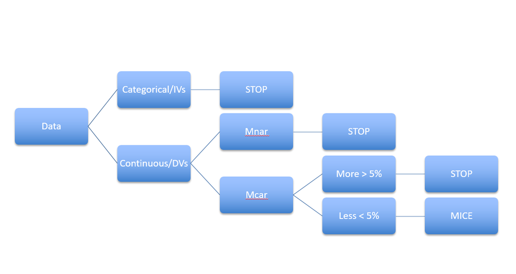

# What do I do with missing data?

- By creating different datasets at each stage of our screening, we can run our analyses with and without missing data replaced to determine if our replacement impacted our results.
- We can exclude entire participants (listwise) with missing data or only when they have have missing data for that analysis (pairwise).

# What do I do with missing data?

- There are multiple estimation methods to “fill-in” missing data if you did not want to remove it.
- Mean substitution was a popular way to estimate missing data by simply estimating the mean for that variable for the missing data points.
  - Conservative - doesn’t change the mean values used to find significant differences.
  - Does change the variance, which may cause type I error with a large number of estimated data points.
- Multiple imputation is now the most popular way to estimate missing data points because computing programs have made this process easier.
  - Creates a set of potential expected values for each missing point.
  - Using matrix algebra, the program estimates the probability of each value and picks the highest one.

# Visualize Missing Data

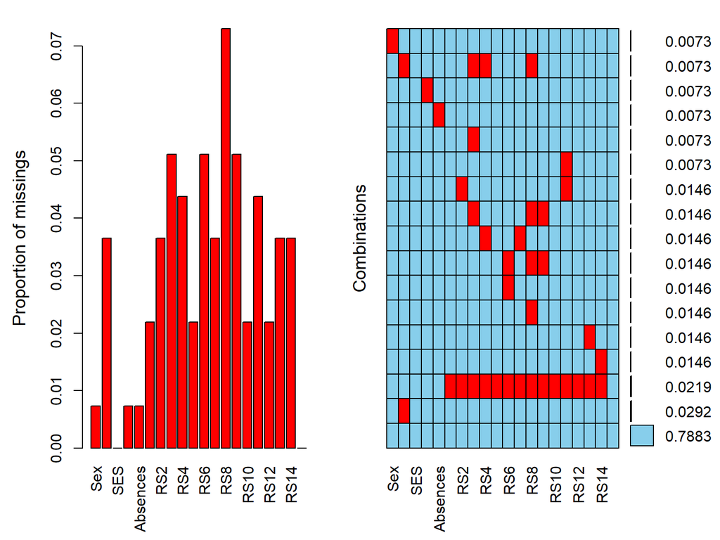

```r
library(VIM, quietly = T)
aggr(notypos, numbers = T)
```

# Replacing Missing Data: Rows

- We will start with examining missing data by rows, as we can exclude incomplete data and rows with too much missing data to replace.
- This table tells us a summary of the missing data - how much is missing in the top row and the number of rows with that missing data in the second row of the table.

```r
percentmiss <- function(x){ sum(is.na(x))/length(x) * 100 }
missing <- apply(notypos, 1, percentmiss)
table(missing)
```

```
## missing
##   0   5  10  15  20  70
## 108  17   4   4   1   3
```

# Replacing Missing Data: Rows

- Create a set of rows to potentially replace.
- If you know you want to include participants *pairwise*, you can also create a set of participants who you will not replace but keep with the dataset.

```r
replace_rows <- subset(notypos, missing <= 5) #5%
noreplace_rows <- subset(notypos, missing > 5)

nrow(notypos)
```

```
## [1] 137
```

```r
nrow(replace_rows)
```

```
## [1] 125
```

```r
nrow(noreplace_rows)
```

```
## [1] 12
```

# Replacing Missing Data: Columns

- Next, we should examine missing data by columns to ensure we do not have **MNAR** data.
- **Note**: We should examine for this missing data on our `replace_rows` because excluding the incomplete data may eliminate any issues by column.

```r
apply(replace_rows, 2, percentmiss)
```

```
##      Sex      Age      SES    Grade Absences      RS1      RS2      RS3
##      0.8      3.2      0.0      0.8      0.8      0.0      0.0      0.8
##      RS4      RS5      RS6      RS7      RS8      RS9     RS10     RS11
##      0.0      0.0      1.6      0.0      1.6      0.0      0.0      0.8
##     RS12     RS13     RS14   Health
##      0.0      1.6      1.6      0.0
```

# Replacing Missing Data: Columns

- Now we will exclude columns that we should not replace missing data for (categorical or demographic data).
- Sex, Age, SES, and Grade are our demographic variables, but you can include variables that do not have missing data to provide a better estimation for the other missing data as `mice` uses all available information to estimate.

```r
replace_columns <- replace_rows[ , -c(1,2,4)]
noreplace_columns <- replace_rows[ , c(1,2,4)] #notice these are both replace_rows
```

# Replacing Missing Data: Using `mice`

- `mice()` will figure out the type of data based on the column structure and replace it with that type of data.
- This function creates several imputations of the data, which we will need to combine back into our original dataset.

```r
library(mice)
temp_no_miss <- mice(replace_columns)
```

# Replacing Missing Data: Using `mice`

```r
nomiss <- complete(temp_no_miss, 1) #pick a dataset 1-5

#combine back together
dim(notypos) #original data from previous step
```

```
## [1] 137  20
```

```r
dim(nomiss) #replaced data
```

```
## [1] 125  17
```

```r
#get all columns
all_columns <- cbind(noreplace_columns, nomiss)
dim(all_columns)
```

```
## [1] 125  20
```

```r
#get all rows
all_rows <- rbind(noreplace_rows, all_columns)
dim(all_rows)
```

```
## [1] 137  20
```

# Outliers

- **Definition** - case with extreme value on one variable or multiple variables.
- Why does an outlier occur?
  - Data input error.
  - “Mindless” participant.
  - Not a population you meant to sample.
  - From the population but has really long tails and very extreme values.
- The logic of removing outliers:
  - Many statistics focus on the mean as a model of the data.
  - The mean is affected by outliers.
  - We will use a strict criterion to only remove very extreme scores.

# Outliers: Types

- **Visual Inspection first:** Field et al. (2012) suggest starting with boxplots and histograms to spot obvious errors (e.g., typos like 20.02 instead of 2.02).
- There are two (2) types:
  - **Univariate** - when you have one (1) DV or Y variable.
    - We can use *Z*-scores with an $\alpha$ of .001 to eliminate very extreme values.
    - This corresponds to a *Z*-score of +/- 3.29 (Field et al., 2012).
    - This analysis is useful when you only have one column to check.
  - **Multivariate** - when you have multiple continuous variables, measurements, or dependent variables.
    - How can we measure distance for many variables at once?
    - **Mahalanobis distance:** It creates a distance from the centroid (the mean of the means).
    - However, because we are creating a scores based on multiple columns, there is not one rule like *Z*-scores.

# Outliers: Mahalanobis

- Mahalanobis distance is distributed using a $\chi^2$ distribution.
- This measure is a distance measure:
  - Distances are always positive!
  - Many scores are close to zero, indicating they are close to the mean of means.
  - Few scores are very large, indicating their scores are very different from everyone else.
  - This type of pattern is not normally distributed, but rather, $\chi^2$.
- How do we know what is very far away?
  - Use a $\chi^2$ distribution with *df* = to the number of variables used to create the score.
  - Use $\alpha$ < .001, as our very strict criterion.
- Again, because we save multiple datasets, we can test the analysis with and without outliers to help us determine their impact on our analyses.

# Outliers: Analyze and Eliminate

- All variables must be numbers for this analysis, because we are calculating the mean of means.
- You could also only analyze for outliers on the data that is provided by participants.
- This stage will potentially eliminate all participants who have any remaining missing data because they will not receive a distance score.

```r
## you can use all columns or all rows here
## however, all rows has missing data, which will not get a score
str(all_columns)
```

```
## 'data.frame':    125 obs. of  20 variables:
##  $ Sex     : Factor w/ 2 levels "Women","Men": 1 1 1 1 1 1 1 1 1 1 ...
##  $ Age     : int  17 16 15 16 15 14 13 15 16 17 ...
##  $ Grade   : int  11 7 6 11 7 6 4 6 8 11 ...
##  $ SES     : Factor w/ 3 levels "Low","Medium",..: 2 3 3 2 3 3 1 2 2 3 ...
##  $ Absences: int  2 2 2 6 2 2 2 2 1 6 ...
##  $ RS1     : int  6 7 5 7 7 2 6 4 3 4 ...
##  $ RS2     : int  4 1 5 4 7 3 6 6 5 3 ...
##  $ RS3     : int  2 1 5 4 7 2 7 6 3 4 ...
##  $ RS4     : int  2 5 7 7 7 3 6 6 2 4 ...
##  $ RS5     : int  4 7 5 4 7 2 1 6 1 4 ...
##  $ RS6     : int  7 7 6 4 7 3 4 6 7 4 ...
##  $ RS7     : int  7 7 5 7 7 3 6 6 4 4 ...
##  $ RS8     : int  4 7 7 7 7 3 6 6 3 7 ...
##  $ RS9     : int  5 4 6 4 7 2 2 6 3 4 ...
##  $ RS10    : int  7 7 7 7 7 2 5 6 3 4 ...
##  $ RS11    : int  4 1 6 7 7 3 6 6 3 6 ...
##  $ RS12    : int  7 7 6 4 7 3 6 6 2 5 ...
##  $ RS13    : int  4 4 6 7 7 2 6 6 5 6 ...
##  $ RS14    : int  7 7 6 4 7 3 2 6 3 4 ...
##  $ Health  : int  6 6 2 6 4 6 1 2 3 1 ...
```

```r
mahal <- mahalanobis(all_columns[ , -c(1,4)],
                    colMeans(all_columns[ , -c(1,4)], na.rm=TRUE),
                    cov(all_columns[ , -c(1,4)], use ="pairwise.complete.obs"))
```

# Outliers: Analyze and Eliminate

```r
## remember to match the number of columns
cutoff <- qchisq(1-.001, ncol(all_columns[ , -c(1,4)]))

## df and cutoff
ncol(all_columns[ , -c(1,4)])
```

```
## [1] 18
```

```r
cutoff
```

```
## [1] 42.3124
```

```r
##how many outliers? Look at FALSE
summary(mahal < cutoff)
```

```
##    Mode   FALSE    TRUE    NA's
## logical       1     119       5
```

```r
## eliminate
noout <- subset(all_columns, mahal < cutoff)
dim(all_columns)
```

```
## [1] 125  20
```

```r
dim(noout)
```

```
## [1] 119  20
```

# Summary

- In this lecture, you have learned:
  - The first several steps to data screening.
  - How to deal with several different types of accuracy issues.
  - How view, exclude, and impute missing data.
  - How to calculate and exclude outliers.

# References

- Field, A., Miles, J., & Field, Z. (2012). *Discovering Statistics Using R*. SAGE Publications.